# Analyse des diagnostics de performance énergétique (DPE)

MBAHOUKA Elk-Fred, TCHETCHE Aristide et PHAM Thi Cam Tien

15/11/2025

*Sélectionner une ville pour afficher les données:*

# 1 **Introduction**

- **Contexte** : Face à la hausse continue des prix de l’énergie et aux enjeux du changement climatique, il est essentiel d’évaluer l’efficacité énergétique des logements afin de mieux orienter les politiques de rénovation et de consommation responsable.
- **Problème** : Les diagnostics de performance énergétique (DPE) ne reflètent pas toujours fidèlement les consommations réelles des occupants, ce qui peut entraîner des décisions inefficaces pour la rénovation énergétique.
- **Objectif** : Cette étude vise à comparer les valeurs théoriques des DPE avec les consommations électriques réelles des logements situés à `Nancy` et `Montpellier`. Ces deux villes ont été choisies car elles représentent des climats contrastés : Nancy étant parmi les villes les plus froides de France, et Montpellier parmi les plus chaudes, ce qui permet d’analyser l’impact du climat sur la performance énergétique.
- **Méthode** : Nous utiliserons des analyses statistiques détaillées sur les données de consommation et de caractéristiques des logements, en classant ces derniers selon leur performance énergétique réelle.
- **Résultat attendu** : Les résultats permettront de mieux cibler les logements nécessitant une rénovation prioritaire et de proposer des recommandations concrètes pour améliorer l’efficacité énergétique, basées sur des données fiables.

# 2 **Analyse des KPI énergétiques et environnementaux**

## 2.1 **Tableau des KPI énergétiques et émissions de CO₂ pour les villes :**

- `n_total = nombre de logements`
- `avg_energy = consommation énergétique moyenne (kWh/m²/an)`
- `pct_A_C = % de logements performants énergétiquement (A-C)`
- `avg_co2 = émissions moyennes de CO₂ (kg/m²/an)`

```r
compute_kpi <- function(df_city) {
df_city %>%
summarise(
n_total = n(),
avg_energy = mean(conso_5_usages_par_m2_ep, na.rm=TRUE),
pct_A_C = sum(etiquette_dpe %in% c("A","B","C"), na.rm=TRUE)/n_total * 100,
avg_co2 = mean(emission_ges_5_usages_par_m2, na.rm=TRUE)
)
}

kpi_nancy <- compute_kpi(df_nancy) %>% mutate(ville="Nancy")
kpi_mtp   <- compute_kpi(df_mtp)   %>% mutate(ville="Montpellier")
kpi_both  <- bind_rows(kpi_nancy, kpi_mtp)

kpi_both
```

```
##   n_total avg_energy  pct_A_C  avg_co2       ville
## 1   51768   199.1458 46.11536 25.38029       Nancy
## 2   54343   183.9675 54.69518 14.35686 Montpellier
```

## 2.2 **KPI pertinents :**

- Pour mieux comprendre la performance énergétique et l’impact environnemental des logements à Nancy et Montpellier, nous avons calculé trois KPI pertinents :
- Ces indicateurs permettent de comparer de manière synthétique les villes sur le plan énergétique :
  - Consommation énergétique moyenne (kWh/m²/an) : reflète l’intensité énergétique des logements et leur efficience.
  - % de logements DPE A–C : montre la proportion de logements considérés comme énergétiquement performants.
  - Émissions moyennes de CO₂ (kg/m²/an) : évalue l’impact environnemental direct lié au chauffage et à la consommation d’énergie.
- Le choix de Nancy et Montpellier permet également d’observer les différences climatiques et leur influence sur ces KPI : Nancy étant l’une des villes les plus froides de France, et Montpellier l’une des plus chaudes. Cette comparaison met en évidence comment le climat peut affecter la consommation énergétique et les émissions de CO₂.

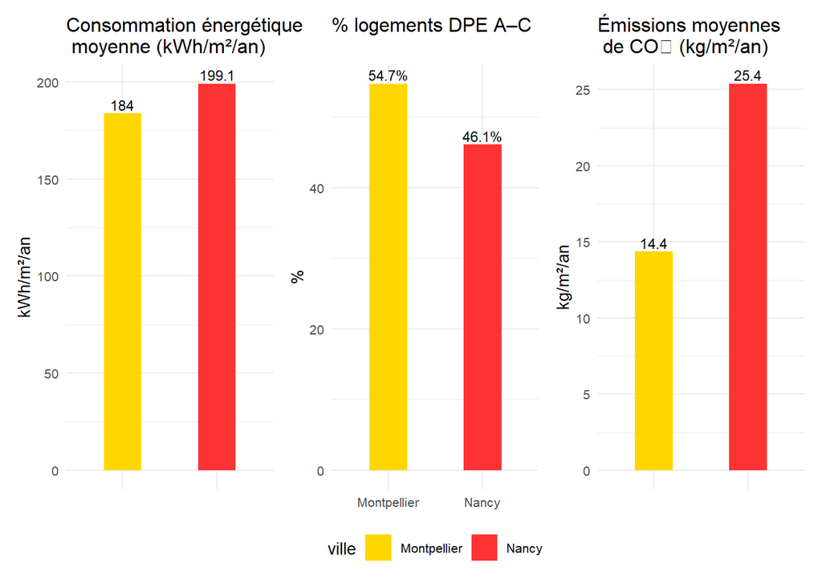

```r
# KPI 1: Consommation moyenne d'énergie ---
p1 <- ggplot(kpi_both, aes(x=ville, y=avg_energy, fill=ville)) +
  geom_col(width=0.4) +
  geom_text(aes(label=round(avg_energy,1)), vjust=-0.3, size=3) +
  labs(title="Consommation énergétique\n moyenne (kWh/m²/an)", x=NULL, y="kWh/m²/an") +
  theme_minimal(base_size = 10) +
  scale_fill_manual(values=c("Nancy"="#FF3333", "Montpellier"="#FFD700")) +
  theme(axis.text.x = element_blank(),
        axis.ticks.x = element_blank(),
        legend.position="none")


# KPI 2: % logements DPE A–C ---
p2 <- ggplot(kpi_both, aes(x=ville, y=pct_A_C, fill=ville)) +
  geom_col(width=0.4) +
  geom_text(aes(label=paste0(round(pct_A_C,1),"%")), vjust=-0.3, size=3) +
  labs(title="% logements DPE A–C", x=NULL, y="%") +
  theme_minimal(base_size = 10) +
  scale_fill_manual(values=c("Nancy"="#FF3333", "Montpellier"="#FFD700")) +
  theme(legend.position="bottom")

# KPI 3: Émissions moyennes de CO₂ ---
p3 <- ggplot(kpi_both, aes(x=ville, y=avg_co2, fill=ville)) +
  geom_col(width=0.4) +
  geom_text(aes(label=round(avg_co2,1)), vjust=-0.3, size=3) +
  labs(title="Émissions moyennes\n de CO₂ (kg/m²/an)", x=NULL, y="kg/m²/an") +
  theme_minimal(base_size = 10) +
  scale_fill_manual(values=c("Nancy"="#FF3333", "Montpellier"="#FFD700")) +
  theme(axis.text.x = element_blank(),
        axis.ticks.x = element_blank(),legend.position="none")


p1 + p2 + p3
```

___